Références du cours

# Livres et lectures

Les lectures du cours renvoient vers des ressources ouvertes et durables. Les livres sont séparés des sites web, guides, articles et aides de fonctions.

Livres Autres lectures et aides Lectures par module

[figure not shown]

[figure not shown]

## Livres

Ces livres peuvent servir de références de fond pour R, la statistique, la visualisation, la reproductibilité et le projet de session.

Wickham, Çetinkaya-Rundel et Grolemund

### R for Data Science, 2e édition

Référence principale pour le tidyverse, l'importation, la transformation, la visualisation, les dates, les jointures et la communication.

[Ouvrir le livre](https://r4ds.hadley.nz/)

[figure not shown]

Çetinkaya-Rundel et Hardin

### Introduction to Modern Statistics

Complément pour l'exploration numérique, l'inférence, l'intuition statistique et l'interprétation appliquée.

[Ouvrir le livre](https://openintrostat.github.io/ims/)

[figure not shown]

Diez, Cetinkaya-Rundel et Barr

### OpenIntro Statistics

Référence ouverte pour revoir les bases statistiques et les raisonnements d'incertitude.

[Ouvrir la ressource](https://www.openintro.org/book/os/)

[figure not shown]

Silge et Robinson

### Text Mining with R

Référence du module 10 pour transformer du texte en données tidy, compter des mots et construire des analyses lexicales.

[Ouvrir le livre](https://www.tidytextmining.com/)

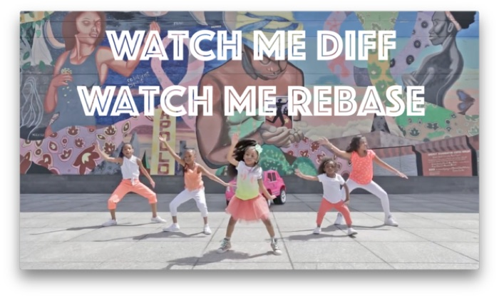

Bryan, STAT 545 TAs et Hester

### Happy Git and GitHub for the useR

Guide pratique pour connecter RStudio, Git et GitHub, comprendre les commits, pousser le travail et collaborer dans un dépôt.

[Ouvrir le livre](https://happygitwithr.com/)

[figure not shown]

Alexander

### Telling Stories with Data

Référence pour construire une analyse complète: question, données, préparation, modélisation, communication et démarche reproductible.

[Ouvrir le livre](https://rohanalexander.github.io/telling_stories-published/)

[figure not shown]

Ismay, Kim et Valdivia

### Statistical Inference via Data Science

Complément pour relier visualisation, transformation, régression et raisonnement statistique avec les outils tidyverse.

[Ouvrir le livre](https://moderndive.com/v2/)

[figure not shown]

Chang

Recettes concrètes pour améliorer des graphiques ggplot2 sans devoir relire toute la théorie à chaque blocage.

[Ouvrir le livre](https://r-graphics.org/)

[figure not shown]

Wilke

### Fundamentals of Data Visualization

Référence ouverte pour choisir des graphiques adaptés et repérer les choix visuels fragiles.

[Ouvrir le livre](https://clauswilke.com/dataviz/)

## Autres lectures et aides

Cette section regroupe les sites web, articles, guides, documentations et aides de fonctions qui soutiennent des gestes précis.

Data  
Org

Broman et Woo

### Data Organization in Spreadsheets

Article de référence pour structurer un tableur avant l'importation, garder les données brutes intactes et documenter les corrections.

[Ouvrir l'article](https://www.tandfonline.com/doi/full/10.1080/00031305.2017.1375989)

tidytext  
tokens

tidytext

### Documentation unnest_tokens()

Documentation de la fonction qui transforme une colonne de texte en tokens dans un tableau tidy.

[Ouvrir la documentation](https://juliasilge.github.io/tidytext/reference/unnest_tokens.html)

tidytext  
TF-IDF

tidytext

### Documentation bind_tf_idf()

Documentation de la fonction qui calcule et ajoute TF, IDF et TF-IDF à un tableau de comptes.

[Ouvrir la documentation](https://juliasilge.github.io/tidytext/reference/bind_tf_idf.html)

flex  
dashboard

Posit

### Documentation flexdashboard

Documentation pour organiser plusieurs visualisations et sorties R dans une page de tableau de bord.

[Ouvrir la documentation](https://rmarkdown.rstudio.com/flexdashboard/)

Shiny  
Dash

Posit

### Using Shiny with flexdashboard

Guide court pour ajouter des entrées interactives et des sorties réactives dans un tableau de bord flexdashboard.

[Ouvrir le guide](https://rstudio.github.io/flexdashboard/articles/shiny.html)

Shiny  
Basics

Posit

### Shiny Basics

Introduction à la structure d'une application interactive et au rôle des entrées et sorties réactives.

[Ouvrir la ressource](https://shiny.posit.co/r/getstarted/shiny-basics/lesson1/)

Tidyverse  
Style

Tidyverse

### The Tidyverse Style Guide

Guide pour écrire du code R lisible, cohérent et plus facile à réviser.

[Ouvrir le guide](https://style.tidyverse.org/)

Quarto  
Docs

Posit

### Documentation Quarto

Documentation officielle pour créer, rendre et publier des documents, rapports et sites Quarto.

[Ouvrir la documentation](https://quarto.org/docs/)

GitHub  
Docs

GitHub

### GitHub Docs

Documentation officielle pour les dépôts, commits, branches, issues et workflows GitHub.

[Ouvrir la documentation](https://docs.github.com/)

rvest  
Docs

Tidyverse

### Documentation rvest

Documentation officielle pour lire une page HTML, sélectionner des éléments, extraire du texte et convertir des tableaux.

[Ouvrir la documentation](https://rvest.tidyverse.org/)

MDN  
robots

MDN Web Docs

### robots.txt

Repère technique pour comprendre le rôle d'un fichier robots.txt dans les consignes données aux robots d'exploration.

[Ouvrir la ressource](https://developer.mozilla.org/en-US/docs/Glossary/Robots.txt)

Google  
robots

Google Search Central

### Introduction to robots.txt

Guide complémentaire pour situer ce que robots.txt peut et ne peut pas contrôler dans l'exploration web.

[Ouvrir la ressource](https://developers.google.com/search/docs/crawling-indexing/robots/intro)

robotstxt  
R

rOpenSci

### Documentation robotstxt

Documentation du package R utilisé pour vérifier si un chemin est autorisé par les règles robots.txt d'un site.

[Ouvrir la documentation](https://docs.ropensci.org/robotstxt/)

R  
lm

R Core Team

### Documentation lm()

Documentation de la fonction R qui ajuste des modèles linéaires et sert de base aux prédictions du module 9.

[Ouvrir la documentation](https://stat.ethz.ch/R-manual/R-devel/library/stats/html/lm.html)

R  
predict

R Core Team

### Documentation predict.lm()

Documentation de la méthode R qui produit des prédictions à partir d'un modèle linéaire ajusté.

[Ouvrir la documentation](https://stat.ethz.ch/R-manual/R-devel/library/stats/html/predict.lm.html)

Canada  
ADM

Gouvernement du Canada

### Guide sur la prise de décisions automatisée

Repère institutionnel pour discuter la transparence, la responsabilité et les limites des systèmes de décision automatisée.

[Ouvrir le guide](https://www.canada.ca/en/government/system/digital-government/digital-government-innovations/responsible-use-ai/guide-scope-directive-automated-decision-making.html)

NIST  
Bias

Schwartz et al.

### NIST SP 1270

Référence pour identifier et gérer les biais possibles dans les systèmes d'intelligence artificielle.

[Ouvrir la ressource](https://www.nist.gov/publications/towards-standard-identifying-and-managing-bias-artificial-intelligence)

RSS  
Guide

Royal Statistical Society

### Best Practices for Data Visualisation

Guide pratique pour rendre les graphiques lisibles, honnêtes et adaptés au message statistique.

[Ouvrir le guide](https://royal-statistical-society.github.io/datavisguide/RSS-data-vis-guide.pdf)

Graph  
Design

Ressource PDF

### Graphics Principles Cheat Sheet

Aide-mémoire pour revoir les principes de conception graphique et améliorer la lisibilité des visualisations.

Télécharger le PDF

Conception  
graphique

Ressource PDF

### Conception graphique

Diaporama sur les principes de conception graphique utiles pour produire des figures plus claires et plus défendables.

Télécharger le PDF

QC  
Données

Gouvernement du Québec

### Anonymisation

Repères institutionnels pour discuter les renseignements personnels, la protection et la publication de données.

[Ouvrir la ressource](https://www.quebec.ca/gouvernement/travailler-gouvernement/normes-gouvernance-pratiques-internes/protection-des-renseignements-personnels/anonymisation)

CNIL  
Guide

CNIL

### L'anonymisation de données personnelles

Référence utile pour distinguer anonymisation, pseudonymisation et risques résiduels.

[Ouvrir la ressource](https://www.cnil.fr/fr/technologies/lanonymisation-de-donnees-personnelles)

Loi 25  
Vidéo

Ressource vidéo

### Guide de la Loi 25

Capsule vidéo pour situer les obligations liées à la protection des renseignements personnels au Québec.

Ouvrir la vidéo

Anonymisation  
HTML

Ressource HTML

### Techniques de base en anonymisation de données

Page de travail sur la suppression des identifiants, la pseudonymisation, les quasi-identifiants et la réduction du risque de réidentification.

Ouvrir la page

Éthique  
PDF

Document de cours

### Pratique responsable en statistique et science des données

Aide-mémoire synthétique pour vérifier les enjeux éthiques liés à la conception, la collecte, l'analyse, la diffusion et l'utilisation des résultats.

Télécharger le PDF

FAIR  
Data

Wilkinson et al.

### FAIR Guiding Principles

Article de référence sur les principes Findable, Accessible, Interoperable et Reusable.

[Ouvrir l'article](https://www.nature.com/articles/sdata201618)

## Lectures par module et projet

Cette synthèse aide à retrouver rapidement les références appelées dans les plans d'apprentissage et les ressources utiles pour le projet de session.

### Module 01

R for Data Science pour situer le flux de travail et Quarto pour comprendre le rapport HTML.

### Module 02

R for Data Science pour visualisation, transformation, exploration et tableurs; Broman et Woo pour organiser les fichiers Excel avant l'analyse.

### Module 03

R for Data Science: chaînes de caractères, facteurs, recodage et repères pour les variables catégorielles.

### Module 04

R for Data Science pour importation, données tidy, valeurs manquantes, facteurs, tableurs, JSON et données imbriquées; Broman et Woo pour les fichiers tabulaires.

### Module 05

R for Data Science pour EDA, dates, visualisation et valeurs manquantes; Introduction to Modern Statistics pour l'exploration numérique; R Graphics Cookbook pour raffiner un graphique.

### Module 06

GitHub Docs et Happy Git pour dépôts, issues, pull requests et conflits; Quarto pour code inline et options d'exécution; R for Data Science pour les jointures.

### Module 07

R for Data Science pour la communication, Wilke, le guide RSS, Graphics Principles Cheat Sheet, Conception graphique et R Graphics Cookbook pour la visualisation responsable, puis Québec, CNIL, Guide de la Loi 25, Techniques de base en anonymisation de données, l'aide-mémoire éthique et FAIR pour l'anonymisation, la confidentialité et la réutilisation des données.

### Module 08

R for Data Science pour HTML, fonctions et itération, rvest pour l'extraction, puis MDN, Google Search Central et robotstxt pour les limites de collecte.

### Module 09

Introduction to Modern Statistics et ModernDive pour la régression simple et multiple, lm() et predict.lm() pour l'implémentation R, puis le guide du Canada et NIST SP 1270 pour la discussion des biais et des décisions automatisées.

### Module 10

Text Mining with R pour le format tidy text, le sentiment et le TF-IDF, unnest_tokens() et bind_tf_idf() pour les fonctions clés, puis flexdashboard, Shiny avec flexdashboard et Shiny Basics pour le tableau de bord interactif.

### Projet de session

Telling Stories with Data pour la démarche complète, Happy Git pour le dépôt, Broman et Woo pour les données tabulaires et Quarto pour la communication reproductible.

## Sources des visuels

Les couvertures reprises ici servent à reconnaître rapidement les ressources principales du cours.

[GPT STT-1100](https://chatgpt.com/g/g-682d165f32e881918633affa3fe9dfd6-gpt-stt-1100)